# Reproducible Research: Peer Assessment 1

Rbotequio

8/4/2020

## Loading and preprocessing the data

```r
setwd("~/Desktop/data/RDPA")
download.file("https://d396qusza40orc.cloudfront.net/repdata%2Fdata%2Factivity.zip", "activity.zip")
unzip(zipfile="./activity.zip")
Acty <- read.csv("activity.csv")
```

Transform date in Date format:

```r
Acty$date <- as.Date(Acty$date)
head(Acty)
```

```
##   steps       date interval
## 1    NA 2012-10-01        0
## 2    NA 2012-10-01        5
## 3    NA 2012-10-01       10
## 4    NA 2012-10-01       15
## 5    NA 2012-10-01       20
## 6    NA 2012-10-01       25
```

Read Libraries

```r
library(data.table)
library(dplyr)
library(lattice)
library(tidyr)
```

## What is mean total number of steps taken per day?

Calculate Total Steps per Day

```r
TStepsDay <- aggregate(steps ~ date, Acty, FUN = sum)
```

[figure not shown]

Mean and Median per day:

```r
MeanSteps <- mean(TStepsDay$steps)
MeanSteps
```

```
## [1] 10766.19
```

```r
MedianSteps <- median(TStepsDay$steps)
MedianSteps
```

```
## [1] 10765
```

## What is the average daily activity pattern?

Calculate the mean of steps per interval of 5 minutes:

```r
aDayInterPat <- Acty %>% group_by(interval) %>% summarise(steps = mean(steps, na.rm = TRUE))
head(aDayInterPat)
```

```
## # A tibble: 6 x 2
##   interval  steps
##      <int>  <dbl>
## 1        0 1.72
## 2        5 0.340
## 3       10 0.132
## 4       15 0.151
## 5       20 0.0755
## 6       25 2.09
```

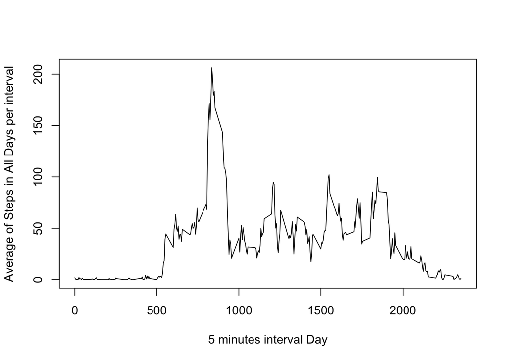

```r
plot(aDayInterPat$interval, aDayInterPat$steps, type = "l", xlab = "5 minutes interval Day", ylab = "Average of Steps in All Days per interval")
```

Which 5-minute interval, on average across all the days in the dataset, contains the maximum number of steps?

```r
fMAxintMean <- aDayInterPat %>% filter(steps == max(steps,  na.rm = TRUE))
fMAxintMean$interval
```

```
## [1] 835
```

## Imputing missing values

Calculate and report the total number of missing values in the dataset (i.e. the total number of rows with NAs)

```r
TotalNAStpes <- sum(is.na(Acty$steps))
TotalNAStpes
```

```
## [1] 2304
```

```r
Acty$CompleteSteps <- ifelse(is.na(Acty$steps), round(aDayInterPat$steps[match(Acty$interval, aDayInterPat$interval)],0), Acty$steps)
head(Acty)
```

```
##   steps       date interval CompleteSteps
## 1    NA 2012-10-01        0             2
## 2    NA 2012-10-01        5             0
## 3    NA 2012-10-01       10             0
## 4    NA 2012-10-01       15             0
## 5    NA 2012-10-01       20             0
## 6    NA 2012-10-01       25             2
```

#Create a new dataset that is equal to the original dataset but with the missing data filled in.

```r
ActyFull <- data.frame(date  = Acty$date, interval = Acty$interval, steps = Acty$CompleteSteps)
head(ActyFull)
```

```
##         date interval steps
## 1 2012-10-01        0     2
## 2 2012-10-01        5     0
## 3 2012-10-01       10     0
## 4 2012-10-01       15     0
## 5 2012-10-01       20     0
## 6 2012-10-01       25     2
```

#Make a histogram of the total number of steps taken each day

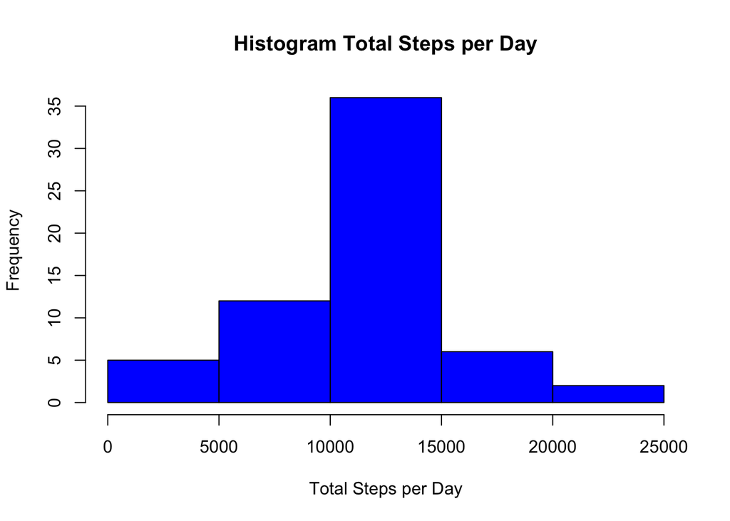

```r
TStepsDayF <- aggregate(steps ~ date, ActyFull, FUN = sum)
hist(TStepsDayF$steps, col = "blue", xlab = "Total Steps per Day", main = "Histogram Total Steps per Day")
```

#Calculate and report the mean and median total number of steps taken per day.

```r
MeanStepsF <- mean(TStepsDayF$steps)
MeanStepsF
```

```
## [1] 10765.64
```

```r
MedianStepsF <- median(TStepsDayF$steps)
MedianStepsF
```

```
## [1] 10762
```

#Do these values differ from the estimates from the first part of the assignment?

```r
DifMedianSteps <- round((MedianSteps-MedianStepsF)/MedianStepsF, 5)
DifMedianSteps
```

```
## [1] 0.00028
```

```r
DifMedianSteps <- round((MeanSteps-MeanStepsF)/MeanStepsF, 10)
DifMedianSteps
```

```
## [1] 5.10267e-05
```

#What is the impact of imputing missing data on the estimates of the total daily number of steps?

[figure not shown]

```r
par(mfrow = c(1, 2))
hist(TStepsDayF$steps, col = "blue", xlab = "Total Steps per Day", main = "Total Steps with NA")
hist(TStepsDay$steps, col = "red", xlab = "Total Steps per Day", main = "Total Steps Filled")
```

```r
summary(TStepsDay)
```

```
##       date                steps
##  Min.   :2012-10-02   Min.   :   41
##  1st Qu.:2012-10-16   1st Qu.: 8841
##  Median :2012-10-29   Median :10765
##  Mean   :2012-10-30   Mean   :10766
##  3rd Qu.:2012-11-16   3rd Qu.:13294
##  Max.   :2012-11-29   Max.   :21194
```

```r
summary(TStepsDayF)
```

```
##       date                steps
##  Min.   :2012-10-01   Min.   :   41
##  1st Qu.:2012-10-16   1st Qu.: 9819
##  Median :2012-10-31   Median :10762
##  Mean   :2012-10-31   Mean   :10766
##  3rd Qu.:2012-11-15   3rd Qu.:12811
##  Max.   :2012-11-30   Max.   :21194
```

## Are there differences in activity patterns between weekdays and weekends?

1. Create a new factor variable in the dataset with two levels – “weekday” and “weekend” indicating whether a given date is a weekday or weekend day.

```r
ActyFull$tDay <- ifelse(weekdays(ActyFull$date) == "Sábado" | weekdays(ActyFull$date, abbreviate = TRUE) == "Domingo", "weekend", "weekday")
head(ActyFull)
```

```
##         date interval steps    tDay
## 1 2012-10-01        0     2 weekday
## 2 2012-10-01        5     0 weekday
## 3 2012-10-01       10     0 weekday
## 4 2012-10-01       15     0 weekday
## 5 2012-10-01       20     0 weekday
## 6 2012-10-01       25     2 weekday
```

2. Make a panel plot containing a time series plot (i.e. type = “l” type = “l”) of the 5-minute interval (x-axis) and the average number of steps taken, averaged across all weekday days or weekend days (y-axis).

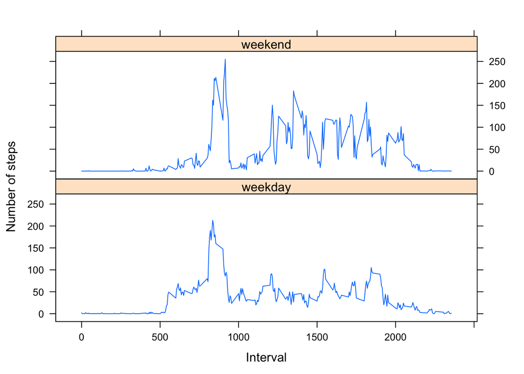

```r
Meaninterweek <- ActyFull %>% group_by(interval, tDay) %>% summarise(steps = mean(steps, na.rm = TRUE))

xyplot(steps ~ interval | tDay, Meaninterweek, type = "l", layout = c(1, 2),
       xlab = "Interval", ylab = "Number of steps")
```